# Data Tool Prototype

# Wealth Disparities: Black Renters are Less Likely to Have Access to Wealth for Down Payments

Due to a legacy of being barred from wealth building opportunities, especially from the post WWII housing boom that created the white middle class, these gaps continue to compound from generation to generation. Thirty percent of white families receive an inheritance or gift, compared to about 10 percent of Black families and 7 percent of Hispanic families. (Bhutta et al. 2020). These wealth disparities echo into all other areas of opportunity, across generations. For example, Black consumers are more likely to rely on student loans to access higher education and tend to borrow more and experience higher rates of default than white consumers, draining savings that may otherwise be put toward buying a home (Blagg et al. 2022).

One report estimates that it would take the typical Latino renter household 11 years and the typical Black renter household 14 years to save for a 5% downpayment; and this does not even factor in closing costs and reserve requirements. Black households are less likely to have had parents who were homeowners and/or owned over $200,000 in wealth, both of which greatly increase the likelihood of becoming an owner (Choi, Zhu & Goodman 2018). The median net worth of parents of young white adults is over $200,000, compared to less than $20,000 for parents of young Black adults and $35,000 for parents of young Latino adults. Gifts from relatives account for approximately 32% percent of down-payments for first-time home buyers (National Association of Realtors 2019), and loans from family and friends are also a substantial source of downpayment (Zillow 2022). More than 1.7 million mortgage-ready young Black renters could afford a median-price home in the 31 most-populous metropolitan statistical areas if they could come up with a funds to close (McCargo, Choi, and Golding 2019).

In 2019, households of color accounted for 32 percent of all households but only held 24 percent of primary-residence housing wealth (Neal et al. 2021, Dettling et al. 2017). Even when they do become homeowners, they often do not reap the same wealth-building benefits as white households. There is evidence that homes owned by people of color as well as homes located in majority non-white communities are systematically undervalued by appraisers (by $48,000 per home on average) and these homes are susceptible to larger errors even in automated-valuations (Perry 2018, Neal, Strochak and Young 2020).

## Median Household Wealth

### Median Wealth by Race, National

Black homebuyers are less likely to have access to wealth for down payments. The median wealth for Black households is $24,000 compared to $188,000 for white households.

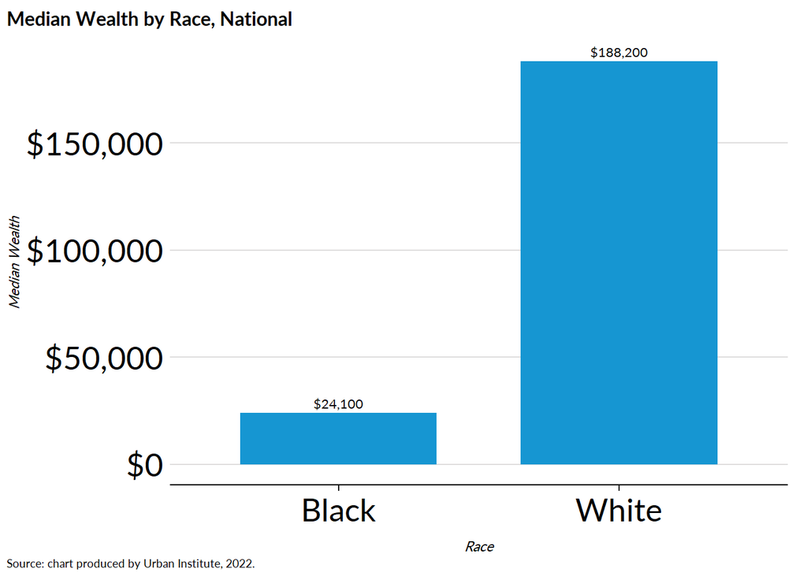

### Median Household Wealth by Race, City

City-level results mirror the national results: in almost all cases the median wealth of white households is greater than the median wealth of black households. In Atlanta, the median wealth of Black households is $5,180, compared to $238,354 for white households.

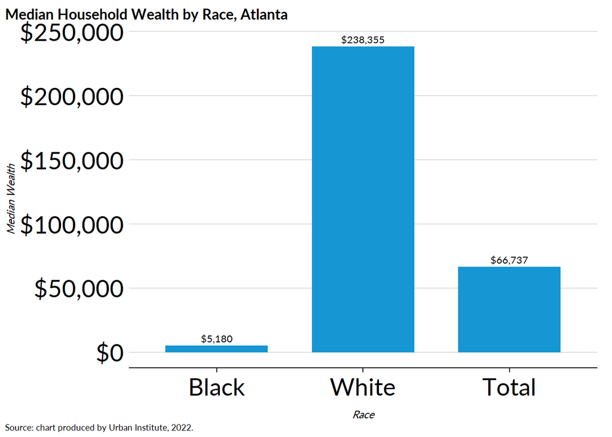

## Cost Burden

### Rental Cost Burden by Race, National

Rental cost burden is just one component driving the wealth gap. Black families are much more likely to spend at least 30% of their income on rent, meaning they have a smaller proportion of their income available to save. Nationally, 51% of Black renter households are cost burdened, compared to only 42% of White households.

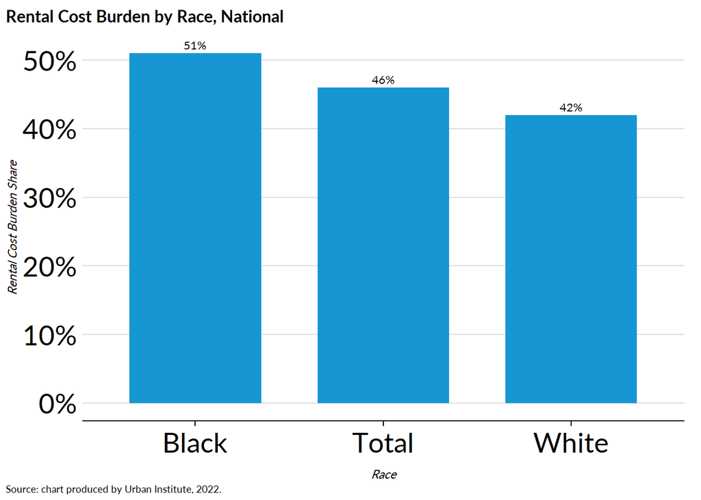

### Rental Cost Burden by Race, MSA

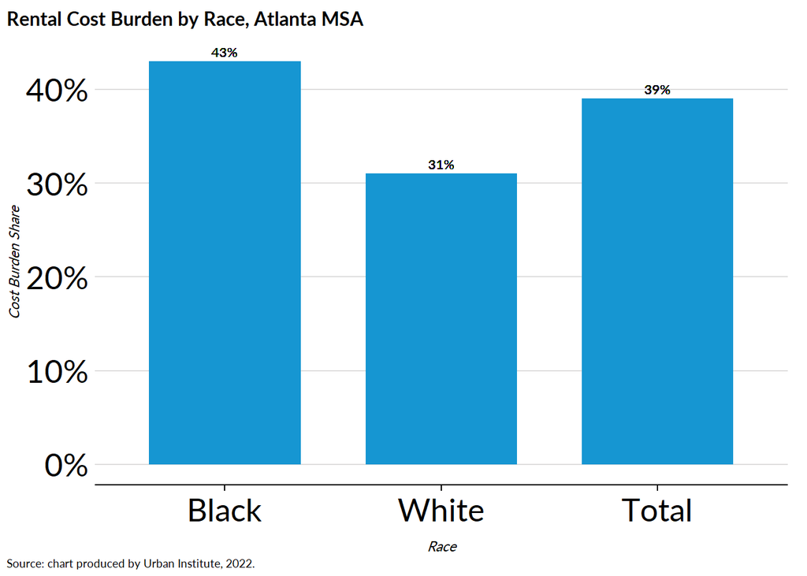

## Wealth and Homeownership

### Wealth by Tenure, National

Homeownership is also a wealth-building vehicle, and the historic homeownership gap has limited wealth building opportunities for Black households. The median net worth for a homeowning household is $255,000, compared to only $6,300 for renters. Importantly, the majority of Black and Latino households are renting households.

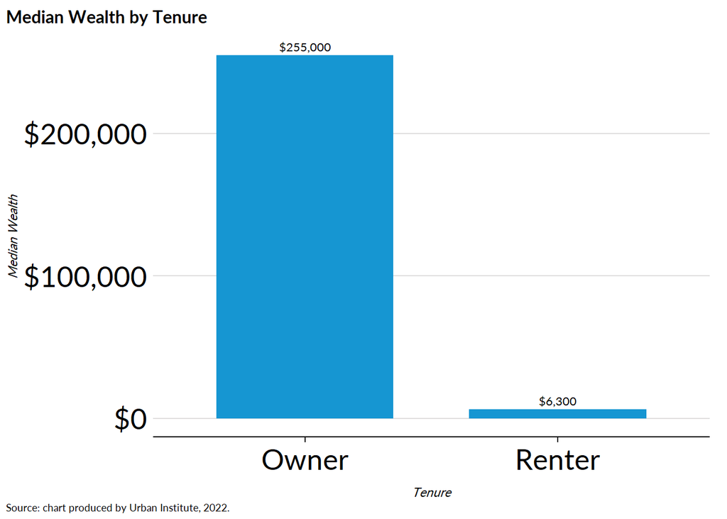

### Homeownership Rate by Parental Wealth, National

Intergenerational wealth transfers also impact the ability to achieve homeownership. Homeownership rates increase as parental wealth increases.

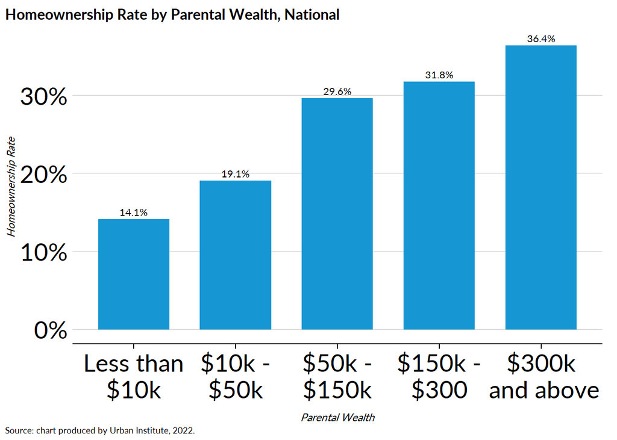

## Race and Downpayments

### Percent of households putting down 5% or below and 20% or above by race, National

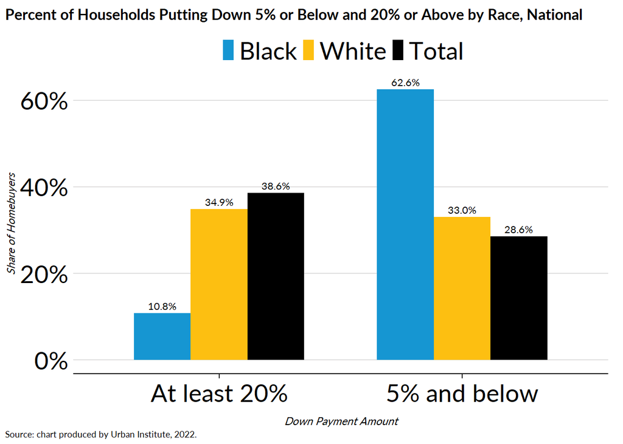

### Percent of households putting down 5% or below and 20% or above by race, MSA

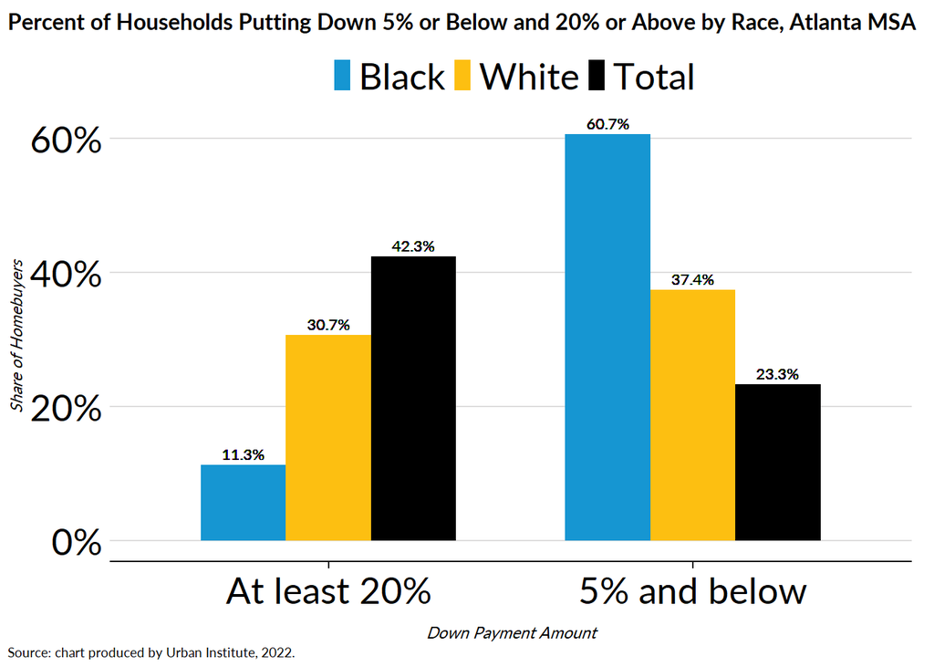

### Used Gov’t or Nonprofit Downpayment Assistance, National

13% of Black households used government or nonprofit downpayment assistance, compared to only 6% of white households, further indicating that Black downpayment savings remain a barrier for Black households.

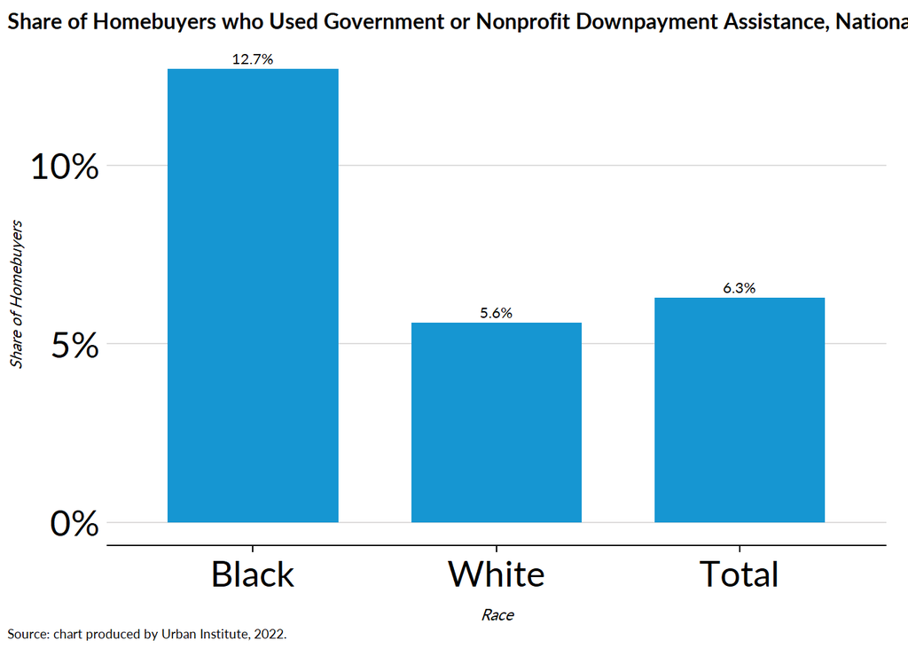